[figure not shown]

# Lecture 01: Introduction

Associated Textbook Sections: [1.0, 1.1, 1.2, 1.3](https://ccsf-math-108.github.io/textbook/chapters/01/what-is-data-science.html)

## Overview

- What is Data Science?
- Insights from Text
- Processing Adventures of Huckleberry Finn
- Visualizing the Story
- Analyzing Little Women
- A Relationship
- What's Next?

## What is Data Science?

### Exploration, Inference, and Prediction

Learning about the world from data using computation:

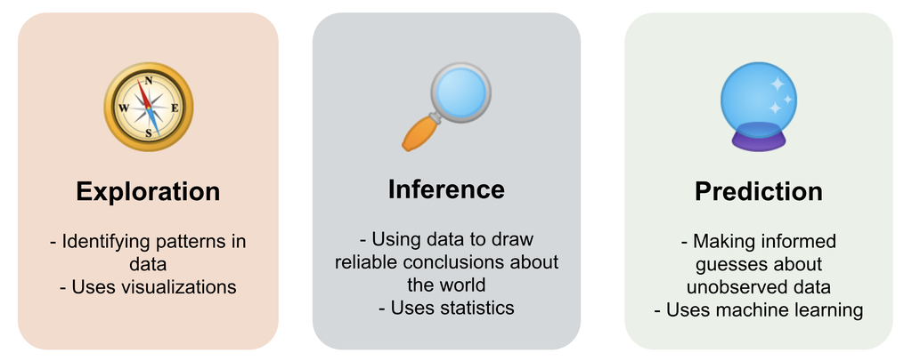

### Job Outlook

According to [the US Bureau of Labor Statistics](https://www.bls.gov/ooh/math/data-scientists.htm):

- Data scientists use analytical tools and techniques to extract meaningful insights from data.
- 2023 Median Pay: $108,020 per year
- Typical Entry-Level Education: Bachelor's degree
- Number of Jobs, 2022: 168,900
- Job Outlook, 2022-32: 35% Increase

### Domain Knowledge and Collaboration

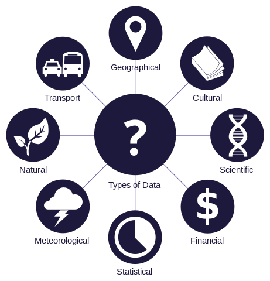

- Data is information that can be used to inform decisions.
- Data exists in many formats: numbers, videos, images, words, etc.
- Interpretation of data depends on the subject domain (topic).
- In our complex world, [cross-functional team collaboration](https://www.linkedin.com/pulse/cross-functional-team-collaboration-data-scientists-okonkwo--zysvf/) is becoming more and more common.
  - In other words, don't expect to work alone as a data scientist!

### Jupyter Notebooks

- Data scientists use a variety of technologies to perform their tasks.
- A [Jupyter Notebook](https://jupyter.org/) is an application that combines:
  - Narrative: The text describing your analysis
  - Code: The program that does the analysis
  - Results: The output of the program
- The Jupyter environment was created by [Fernando Perez](https://bids.berkeley.edu/people/fernando-perez) at UC Berkeley.
- - The Jupyter notebooks contain computer code written in a language called [Python](https://www.python.org/).
- You will learn the basics of working with these notebooks and Python over the next few lessons and assignments.

**Note: This notebook contains Python code you are not responsible for understanding in this course.**

## Insights from Text

### Python "Reads" Two Books

[figure not shown]

[figure not shown]

- [Project Gutenberg](https://www.gutenberg.org/) contains public domain book data.
- The processing of natural languages ([NLP](https://en.wikipedia.org/wiki/Natural_language_processing)) is a major focus of research and application right now.
- The following code loads the text from the Adventures of Huckleberry Finn and Little Women into this environment.

```python
with open("./huck_finn.txt") as huck_finn, \
open("./little_women.txt") as little_women:
    huck_finn_chapters = huck_finn.read().split('CHAPTER ')[44:]
    little_women_chapters = little_women.read().split('CHAPTER ')[1:]
```

### Preview the Data

The following code shows the first 100 characters of Chapter 1 from both books.

```python
huck_finn_chapters[0][:100]
```

```
"I.\n\nYOU don't know about me without you have read a book by the name of The\nAdventures of Tom Sawyer"
```

```python
little_women_chapters[0][:100]
```

```
'ONE\n\nPLAYING PILGRIMS\n\n"Christmas won\'t be Christmas without any presents," grumbled Jo, lying\non th'
```

The data might not look like you expect it to!

### datascience

- Data Science tasks regularly involve transforming data for analysis.
- We will use UC Berkeley's [`datascience`](https://datascience.readthedocs.io/) library (a collection of code) to do most of our coding work.
- The `datascience` library was designed to help students transition from having no coding experience to using more professional libraries such as [`pandas`](https://pandas.pydata.org/).

### Import `datascience`

- The following code imports all of the content of the `datascience` library.
- Notice that the word `Table` (case-sensitive) has a special meaning.

```python
from datascience import *
```

```python
Table
```

```
datascience.tables.Table
```

## Processing Adventures of Huckleberry Finn

### Create a Table

The following code organizes all the text from each chapter of the book within a `Table`.

```python
Table().with_column('Chapters', huck_finn_chapters)
```

| Chapters |
| --- |
| I. YOU don't know about me without you have read a book ... |
| II. WE went tiptoeing along a path amongst the trees ba ... |
| III. WELL, I got a good going-over in the morning from ... |
| IV. WELL, three or four months run along, and it was we ... |
| V. I had shut the door to. Then I turned around and th ... |
| VI. WELL, pretty soon the old man was up and around aga ... |
| VII. "GIT up! What you 'bout?" I opened my eyes and l ... |
| VIII. THE sun was up so high when I waked that I judged ... |
| IX. I wanted to go and look at a place right about the ... |
| X. AFTER breakfast I wanted to talk about the dead man ... |

... (33 rows omitted)

### Word Frequency

What can the frequency of words in a story tell us about the story?

- Counting words in a book might seem overwhelming.
- Computers can help with tedious tasks like this.

### NumPy

- [`numpy`](https://numpy.org/) is another standard library that you work within this course.
- This library will help with performing repetitive calculations.

### Import `numpy`

The following code imports the `numpy` library and give it the alias `np`.

```python
import numpy as np
```

### Counting Names with NumPy

The following code counts the number of times "Tom" and "Jim" appear in the text.

```python
np.char.count(huck_finn_chapters, 'Tom')
```

```
array([ 6, 24,  5,  0,  0,  0,  2,  2,  0,  0,  2,  3,  1,  0,  0,  0,  3,
        5,  0,  0,  0,  0,  0,  0,  0,  0,  0,  1,  0,  0,  1,  4, 19, 15,
       14, 18,  9, 32, 11, 11,  8, 30,  6])
```

```python
np.char.count(huck_finn_chapters, 'Jim')
```

```
array([ 0, 16,  0,  8,  0,  0,  0, 22, 11, 19,  4, 20,  9,  6, 16, 28,  0,
       10, 13, 18,  1,  0,  9,  5,  0,  0,  0,  1,  3,  5, 17,  0,  5, 17,
       18, 23,  4, 27, 10, 13,  0, 12,  6])
```

```python
np.char.count(huck_finn_chapters, 'The')
```

```
array([12, 10,  7,  8, 14, 20, 20, 18, 16,  6, 18, 12, 11,  5,  9, 14, 40,
       34, 13, 33, 46, 18, 12, 15, 22, 28, 32, 22, 26, 14, 16,  7, 13, 11,
       12,  6, 11,  8,  9,  7,  4, 14, 14])
```

```python
np.char.count(huck_finn_chapters, 'the')
```

```
array([ 76, 170, 130,  71,  90, 195, 231, 218, 128,  97, 186, 207, 154,
        67, 134, 173, 224, 310, 264, 269, 273, 182, 153, 183, 272, 216,
       262, 242, 331,  69, 238, 170, 131, 105, 168, 130, 196, 121, 192,
       175, 147, 172, 204])
```

### Creating Another Table

The following code creates a table called `counts` that organizes the frequency of the names Jim, Tom, and Huck within each chapter.

```python
counts_hf = Table().with_columns([
    'Tom', np.char.count(huck_finn_chapters, 'Tom'),
    'Jim', np.char.count(huck_finn_chapters, 'Jim'),
    'Huck', np.char.count(huck_finn_chapters, 'Huck'),
])
counts_hf
```

| Tom | Jim | Huck |
| --- | --- | --- |
| 6 | 0 | 3 |
| 24 | 16 | 2 |
| 5 | 0 | 2 |
| 0 | 8 | 1 |
| 0 | 0 | 0 |
| 0 | 0 | 2 |
| 2 | 0 | 0 |
| 2 | 22 | 5 |
| 0 | 11 | 1 |
| 0 | 19 | 0 |

... (33 rows omitted)

That is a lot of numbers!

## Visualizing the Story

### Matplotlib

- Visualizations help summarize data and allow us to see patterns.
- [Matplotlib](https://matplotlib.org/) is a standard Python visualization library.
- In this course, we will use it *indirectly* to create visualizations.

### Import and Configure `matplotlib`

The following code imports and configures `matplotlib`.

```python
%matplotlib inline
import matplotlib.pyplot as plt
plt.style.use('fivethirtyeight')
```

### Visualize a Trend

- Run the following code to visualize how the cumulative counts for each person change over the chapters.
- When you create a graph, observe patterns and ask questions.
  - Do you notice any interesting patterns in the lines?
  - Why might those patterns exist?

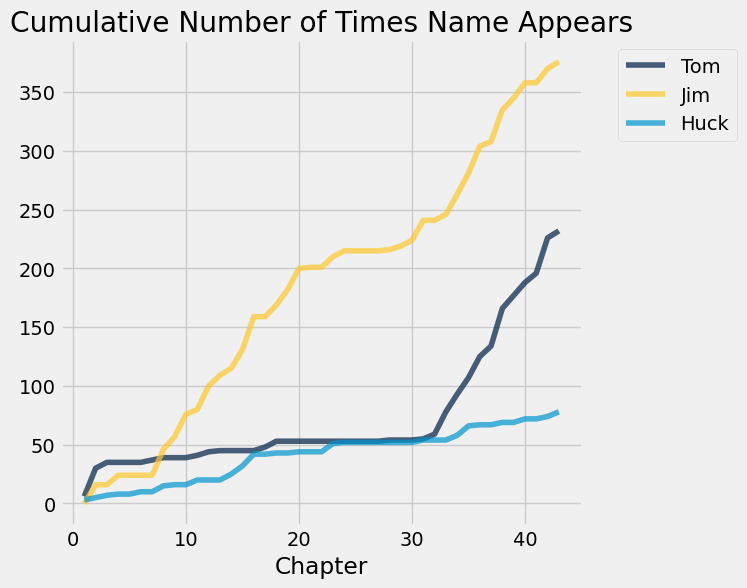

```python
original_labels_hf =  list(counts_hf.labels)
cumulative_values_hf = ([np.cumsum(counts_hf.column(index))
                         for index in np.arange(counts_hf.num_columns)])
cumulative_counts_hf = (counts_hf
                        .with_columns(zip(original_labels_hf, cumulative_values_hf))
                        .with_column('Chapter', np.arange(1, 44, 1)))
cumulative_counts_hf.plot('Chapter')
plt.title('Cumulative Number of Times Name Appears')
plt.show()
```

## Analyzing Little Women

### Create a Table

The following code organizes the text from each chapter from Little Women within a `Table`.

```python
Table().with_column('Chapters', little_women_chapters)
```

| Chapters |
| --- |
| ONE PLAYING PILGRIMS "Christmas won't be Christmas wit ... |
| TWO A MERRY CHRISTMAS Jo was the first to wake in the ... |
| THREE THE LAURENCE BOY "Jo! Jo! Where are you?" crie ... |
| FOUR BURDENS "Oh, dear, how hard it does seem to take ... |
| FIVE BEING NEIGHBORLY "What in the world are you going ... |
| SIX BETH FINDS THE PALACE BEAUTIFUL The big house did ... |
| SEVEN AMY'S VALLEY OF HUMILIATION "That boy is a perfe ... |
| EIGHT JO MEETS APOLLYON "Girls, where are you going?" ... |
| NINE MEG GOES TO VANITY FAIR "I do think it was the mo ... |
| TEN THE P.C. AND P.O. As spring came on, a new set of ... |

... (37 rows omitted)

### Counting Names

The following code counts how often the names of some characters in Little Women appear within each chapter.

```python
people_lw = ['Amy', 'Beth', 'Jo', 'Laurie', 'Meg']
counts_lw = {pp: np.char.count(little_women_chapters, pp) for pp in people_lw}

counts_lw = Table().with_columns([
        'Amy', counts_lw['Amy'],
        'Beth',counts_lw['Beth'],
        'Jo', counts_lw['Jo'],
        'Laurie', counts_lw['Laurie'],
        'Meg', counts_lw['Meg']
    ])
counts_lw
```

| Amy | Beth | Jo | Laurie | Meg |
| --- | --- | --- | --- | --- |
| 23 | 26 | 44 | 0 | 26 |
| 13 | 12 | 21 | 0 | 20 |
| 2 | 2 | 62 | 16 | 36 |
| 14 | 18 | 34 | 0 | 17 |
| 6 | 14 | 55 | 35 | 13 |
| 6 | 28 | 13 | 9 | 5 |
| 27 | 5 | 9 | 7 | 5 |
| 48 | 9 | 71 | 17 | 16 |
| 3 | 5 | 21 | 24 | 71 |
| 5 | 5 | 12 | 4 | 4 |

... (37 rows omitted)

### Visualize a Trend

- Use the following code to visualize how the cumulative counts for each person change over the chapters.
- What do you notice in this visualization?

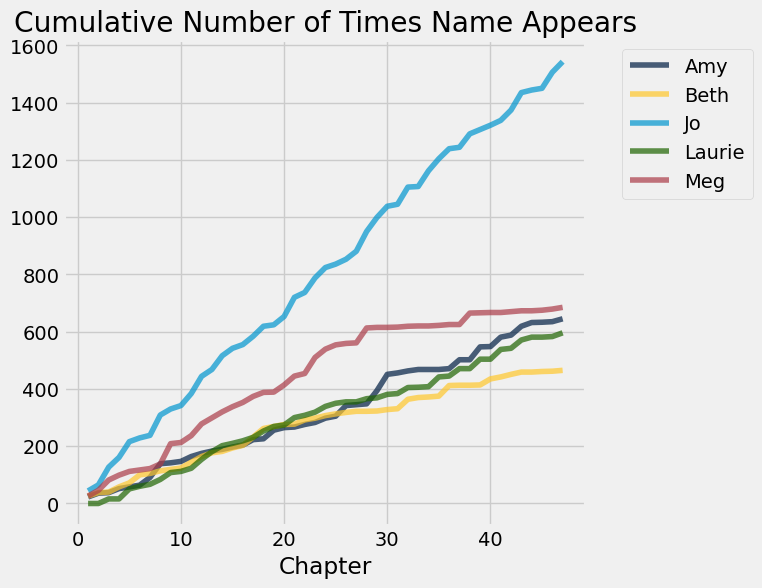

```python
original_labels_lw =  list(counts_lw.labels)
cumulative_values_lw = ([np.cumsum(counts_lw.column(index))
                      for index in np.arange(counts_lw.num_columns)])
cumulative_counts_lw = (counts_lw
                        .with_columns(zip(original_labels_lw, cumulative_values_lw))
                        .with_column('Chapter', np.arange(1, 48, 1)))
cumulative_counts_lw.plot('Chapter')
plt.title('Cumulative Number of Times Name Appears')
plt.show()
```

## A Relationship

### Chapter Length vs. Sentence Length

- Is there a relationship between the length of a chapter and the number of sentences in that chapter?
- To explore this determine:
  - Chapter length: A count of all the symbolic characters of the chapter.
  - Sentence Length: An approximate count of the number of sentences in each chapter.

### Create Some Tools

- Data Science usually requires us to create tools.
- The following code creates some tools for us to use:
  - `count_characters`: Counts the number of symbolic characters per chapter.
  - `count_sentences`: Counts the number of periods, question marks, and exclamation points per chapter to provide an estimate of the number of sentences in each chapter.

```python
def count_characters(book_by_chapters):
    '''Return the count of the number of characters
    per chapter of the provided book.'''
    return [len(s) for s in book_by_chapters]
```

```python
def count_sentences(book_by_chapters):
    '''Return the count of the number of periods, question marks,
    and exclamation points per chapter of the provided book.'''
    punctuation = ['.', '?', '!']
    num_sentences = np.zeros_like(book_by_chapters, dtype=int)
    for char in punctuation:
        num_sentences += np.char.count(book_by_chapters, char)
    return num_sentences
```

### Apply the Tools

Use the following code to determine the length of every chapter and the number of sentences per chapter of both books.

```python
chapter_lengths_hf = count_characters(huck_finn_chapters)
number_of_sentences_hf = count_sentences(huck_finn_chapters)
chars_sentences_hf = Table().with_columns(
    'Number of Sentences', number_of_sentences_hf,
    'Chapter Length', chapter_lengths_hf,
    'Book', ['Huck Finn'] * len(huck_finn_chapters))

chapter_lengths_lw = count_characters(little_women_chapters)
number_of_sentences_lw = count_sentences(little_women_chapters)
chars_sentences_lw = Table().with_columns(
    'Number of Sentences', number_of_sentences_lw,
    'Chapter Length', chapter_lengths_lw,
    'Book', ['Little Women'] * len(little_women_chapters))
```

### Explore the Results

- Show the results for Huck Finn and Little Women
- Combine the two tables into one table.

```python
chars_sentences_hf
```

| Number of Sentences | Chapter Length | Book |
| --- | --- | --- |
| 72 | 7088 | Huck Finn |
| 144 | 12113 | Huck Finn |
| 82 | 8612 | Huck Finn |
| 93 | 6892 | Huck Finn |
| 105 | 8269 | Huck Finn |
| 139 | 14672 | Huck Finn |
| 136 | 13349 | Huck Finn |
| 289 | 22483 | Huck Finn |
| 74 | 8153 | Huck Finn |
| 73 | 7109 | Huck Finn |

... (33 rows omitted)

```python
chars_sentences_lw
```

[output not shown]

```python
chars_sentences = chars_sentences_hf.append(chars_sentences_lw)
chars_sentences
```

| Number of Sentences | Chapter Length | Book |
| --- | --- | --- |
| 72 | 7088 | Huck Finn |
| 144 | 12113 | Huck Finn |
| 82 | 8612 | Huck Finn |
| 93 | 6892 | Huck Finn |
| 105 | 8269 | Huck Finn |
| 139 | 14672 | Huck Finn |
| 136 | 13349 | Huck Finn |
| 289 | 22483 | Huck Finn |
| 74 | 8153 | Huck Finn |
| 73 | 7109 | Huck Finn |

... (80 rows omitted)

### Visualizing the Relationship

- Use the following code to visualize the relationship between the length of a chapter and the number of sentences in the same chapter.
- What do you notice about the pattern of the dots?

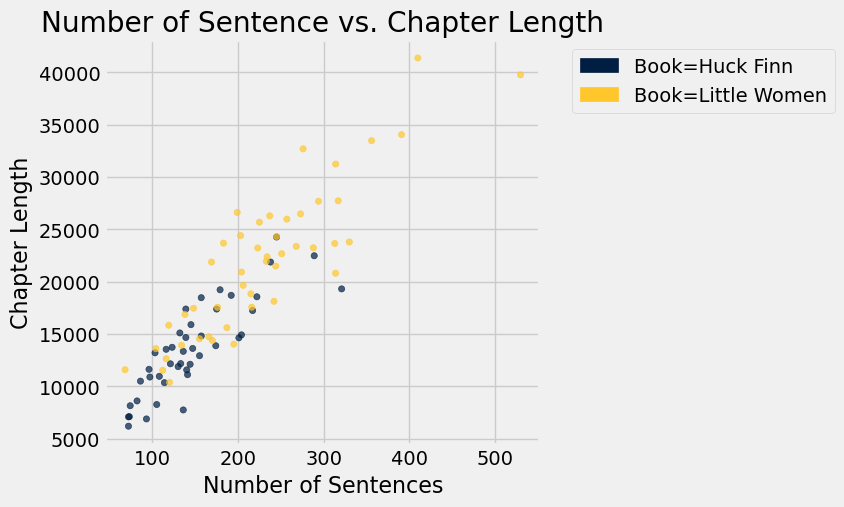

```python
chars_sentences.scatter('Number of Sentences', group='Book')
plt.title('Number of Sentence vs. Chapter Length')
plt.show()
```

### Quantifying the Relationship

The following code computes the ratio of the average chapter length with the average number of sentences per chapter for each book.

```python
ave_sentence_length_hf = (np.average(chapter_lengths_hf)
                          / np.average(number_of_sentences_hf))
print(f'Huck Finn has an average approximate sentence \
length of {ave_sentence_length_hf} characters.')
```

[output not shown]

```python
ave_sentence_length_lw = (np.average(chapter_lengths_lw)
                          / np.average(number_of_sentences_lw))
print(f'Little Women has an average approximate sentence \
length of {ave_sentence_length_lw} characters.')
```

[output not shown]

## What's Next?

### A Life Cycle

A typical cycle involved with this type of work is:

[output not shown]

The end of each project should prompt another project!

## Attribution

This content is licensed under the Creative Commons Attribution-NonCommercial-ShareAlike 4.0 International License (CC BY-NC-SA 4.0) and derived from the Data 8: The Foundations of Data Science offered by the University of California, Berkeley.